# PCIT-CoS-Waitlist RCT Paper 1: Observed maternal negativity (NICHD), Controlling for ASD

Nancy Briggs

05 JAN 2021

#### Descriptives

Raw Data

| group | time | n | mean | sd | median | min | max |
| --- | --- | --- | --- | --- | --- | --- | --- |
| 1 | NA | NA | NA | NA | NA | NA | NA |
| 1 | 1 | 23 | 6.761 | 2.335 | 6.0 | 5 | 14.0 |
| 1 | 2 | 18 | 5.278 | 0.575 | 5.0 | 5 | 7.0 |
| 1 | 3 | 12 | 5.250 | 0.452 | 5.0 | 5 | 6.0 |
| 2 | NA | NA | NA | NA | NA | NA | NA |
| 2 | 1 | 25 | 7.360 | 2.361 | 7.0 | 5 | 12.0 |
| 2 | 2 | 10 | 6.900 | 2.183 | 6.5 | 5 | 11.0 |
| 2 | 3 | 4 | 7.250 | 2.217 | 7.0 | 5 | 10.0 |
| 3 | NA | NA | NA | NA | NA | NA | NA |
| 3 | 1 | 22 | 7.255 | 1.912 | 7.0 | 5 | 10.0 |
| 3 | 2 | 17 | 6.647 | 1.835 | 6.0 | 5 | 11.0 |
| 3 | 3 | 0 | NaN | NA | NA | Inf | -Inf |
| 1 | NA | NA | NA | NA | NA | NA | NA |
| 1 | 1 | 6 | 7.000 | 2.530 | 6.0 | 5 | 12.0 |
| 1 | 2 | 3 | 5.333 | 0.577 | 5.0 | 5 | 6.0 |
| 1 | 3 | 4 | 6.000 | 1.414 | 5.5 | 5 | 8.0 |
| 2 | NA | NA | NA | NA | NA | NA | NA |
| 2 | 1 | 3 | 9.000 | 3.606 | 10.0 | 5 | 12.0 |
| 2 | 2 | 2 | 7.000 | 2.828 | 7.0 | 5 | 9.0 |
| 2 | 3 | 0 | NaN | NA | NA | Inf | -Inf |
| 3 | NA | NA | NA | NA | NA | NA | NA |
| 3 | 1 | 5 | 8.400 | 3.050 | 8.0 | 5 | 12.0 |
| 3 | 2 | 4 | 6.800 | 1.327 | 7.0 | 5 | 8.2 |
| 3 | 3 | 0 | NaN | NA | NA | Inf | -Inf |

Note:  
One person the Waitlist has a value at Follow Up. It has been set to missing.

Log Transformed Data

| group | time | n | mean | sd | median | min | max |
| --- | --- | --- | --- | --- | --- | --- | --- |
| 1 | NA | NA | NA | NA | NA | NA | NA |
| 1 | 1 | 23 | 1.863 | 0.304 | 1.792 | 1.609 | 2.639 |
| 1 | 2 | 18 | 1.659 | 0.100 | 1.609 | 1.609 | 1.946 |
| 1 | 3 | 12 | 1.655 | 0.082 | 1.609 | 1.609 | 1.792 |
| 2 | NA | NA | NA | NA | NA | NA | NA |
| 2 | 1 | 25 | 1.948 | 0.314 | 1.946 | 1.609 | 2.485 |
| 2 | 2 | 10 | 1.890 | 0.297 | 1.869 | 1.609 | 2.398 |
| 2 | 3 | 4 | 1.946 | 0.307 | 1.936 | 1.609 | 2.303 |
| 3 | NA | NA | NA | NA | NA | NA | NA |
| 3 | 1 | 22 | 1.948 | 0.268 | 1.946 | 1.609 | 2.303 |
| 3 | 2 | 17 | 1.862 | 0.256 | 1.792 | 1.609 | 2.398 |
| 3 | 3 | 0 | NaN | NA | NA | Inf | -Inf |
| 1 | NA | NA | NA | NA | NA | NA | NA |
| 1 | 1 | 6 | 1.903 | 0.305 | 1.792 | 1.609 | 2.485 |
| 1 | 2 | 3 | 1.670 | 0.105 | 1.609 | 1.609 | 1.792 |
| 1 | 3 | 4 | 1.773 | 0.222 | 1.701 | 1.609 | 2.079 |
| 2 | NA | NA | NA | NA | NA | NA | NA |
| 2 | 1 | 3 | 2.132 | 0.462 | 2.303 | 1.609 | 2.485 |
| 2 | 2 | 2 | 1.903 | 0.416 | 1.903 | 1.609 | 2.197 |
| 2 | 3 | 0 | NaN | NA | NA | Inf | -Inf |
| 3 | NA | NA | NA | NA | NA | NA | NA |
| 3 | 1 | 5 | 2.073 | 0.377 | 2.079 | 1.609 | 2.485 |
| 3 | 2 | 4 | 1.901 | 0.208 | 1.946 | 1.609 | 2.104 |
| 3 | 3 | 0 | NaN | NA | NA | Inf | -Inf |

Note:  
One person the Waitlist has a value at Follow Up. It has been set to missing.  
<sup>1</sup> Data are log transofrmed because residuals from an analysis of the raw data violated assumptions in the model.

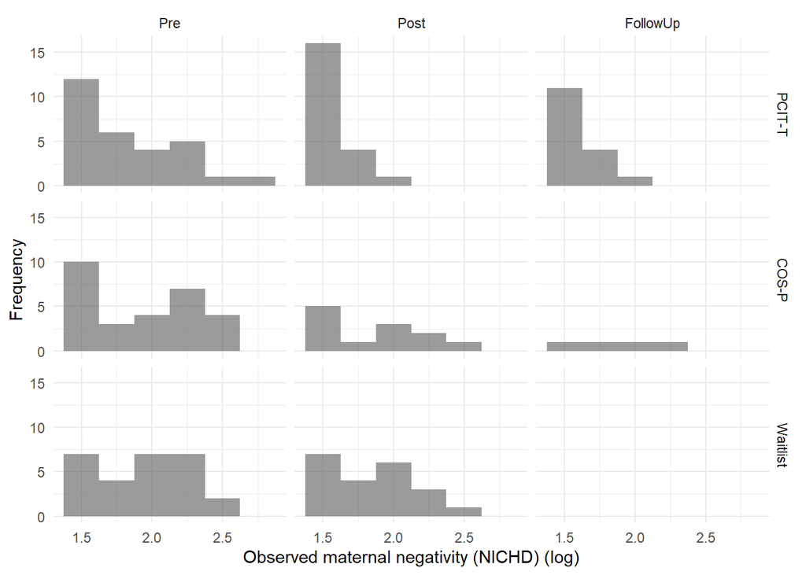

#### Model & Results

A linear mixed model with random effect for individual and fixed effects of group, time and the interaction was run. ASD status was then entered into the model as a main effect and then the 3-way interaction. Estimated marginal means were obtained, and contrasts specified to test Hypothesis 1 and Hypothesis 2.

```
## fixed-effect model matrix is rank deficient so dropping 1 column / coefficient
```

```
## fixed-effect model matrix is rank deficient so dropping 3 columns / coefficients
```

This is the ANOVA table for the model. p-values are likelihood ratio tests for adding the new term to the model just before. A p-value <0.05 indicates that adding that term results in better model fit. The most important p-value is the interaction p-value.

```
## refitting model(s) with ML (instead of REML)
```

[output not shown]

There is no evidence that ASD moderates the 2-way group*time interaction (the 3-way interaction p=0.803).

Model3, the model with Group*Time, adjusted by ASD will be the model I use for Estimated Means.

```r
summary(result3)
```

```
## Linear mixed model fit by REML. t-tests use Satterthwaite's method [
## lmerModLmerTest]
## Formula: outcome ~ asdcase + group * time + (1 | id)
##    Data: dat
##
## REML criterion at convergence: 32.3
##
## Scaled residuals:
##     Min      1Q  Median      3Q     Max
## -1.7584 -0.6724 -0.0161  0.5629  2.8701
##
## Random effects:
##  Groups   Name        Variance Std.Dev.
##  id       (Intercept) 0.04318  0.2078
##  Residual             0.03155  0.1776
## Number of obs: 158, groups:  id, 86
##
## Fixed effects:
##               Estimate Std. Error        df t value Pr(>|t|)
## (Intercept)    1.85902    0.05296  99.64313  35.100  < 2e-16 ***
## asdcase1       0.06020    0.07302  66.60483   0.824 0.412677
## group2         0.09365    0.07256 104.16817   1.291 0.199680
## group3         0.11245    0.07291 104.67361   1.542 0.125986
## time2         -0.20744    0.05309  63.75712  -3.908 0.000228 ***
## time3         -0.15407    0.05882  65.45770  -2.620 0.010932 *
## group2:time2   0.22336    0.08697  71.68413   2.568 0.012309 *
## group3:time2   0.08647    0.07589  64.69112   1.139 0.258715
## group2:time3   0.29580    0.12690  78.12019   2.331 0.022333 *
## ---
## Signif. codes:  0 '***' 0.001 '**' 0.01 '*' 0.05 '.' 0.1 ' ' 1
##
## Correlation of Fixed Effects:
##             (Intr) asdcs1 group2 group3 time2  time3  grp2:2 grp3:2
## asdcase1    -0.285
## group2      -0.700  0.103
## group3      -0.675  0.026  0.490
## time2       -0.395  0.029  0.285  0.282
## time3       -0.346 -0.011  0.254  0.253  0.408
## group2:tim2  0.247 -0.038 -0.364 -0.173 -0.611 -0.249
## group3:tim2  0.277 -0.022 -0.200 -0.415 -0.700 -0.285  0.427
## group2:tim3  0.156  0.021 -0.255 -0.117 -0.189 -0.464  0.293  0.132
## fit warnings:
## fixed-effect model matrix is rank deficient so dropping 1 column / coefficient
```

#### Estimated Means & Change

Estimated means for each Treatment and Time (adjusted by ASD status) are presented. In addition, within-group change between time points is presented with 95% CIs.

##### Group mean difference at each timepoint

Effect sizes all calculated by the pooled T1 SD of the outcome. Adjusted p-value from Bonferroni correction.

Group Differences at Each Time Point

| Group Difference | Time | Mean | SE | t | p | adj p | Lower CL | Upper CL | Effect Size | Lower CL | Upper CL |
| --- | --- | --- | --- | --- | --- | --- | --- | --- | --- | --- | --- |
| 1 - 2 | 1 | -0.094 | 0.073 | -1.291 | 0.403 | 0.598 | -0.266 | 0.079 | -0.299 | -0.834 | 0.164 |
| 1 - 3 | 1 | -0.112 | 0.073 | -1.542 | 0.275 | 0.377 | -0.286 | 0.061 | -0.359 | -0.958 | 0.124 |
| 2 - 3 | 1 | -0.019 | 0.073 | -0.256 | 0.965 | 1.000 | -0.193 | 0.156 | -0.060 | -0.541 | 0.399 |
| 1 - 2 | 2 | -0.317 | 0.091 | -3.481 | 0.002 | 0.002 | -0.533 | -0.101 | -1.013 | -1.905 | -0.524 |
| 1 - 3 | 2 | -0.199 | 0.081 | -2.467 | 0.039 | 0.045 | -0.390 | -0.008 | -0.635 | -1.296 | -0.160 |
| 2 - 3 | 2 | 0.118 | 0.091 | 1.293 | 0.401 | 0.594 | -0.098 | 0.334 | 0.377 | -0.200 | 1.114 |
| 1 - 2 | 3 | -0.389 | 0.130 | -3.000 | 0.009 | 0.010 | -0.697 | -0.082 | -1.244 | -2.423 | -0.523 |
| 1 - 3 | 3 | NA | NA | NA | NA | NA | NA | NA | NA | NA | NA |
| 2 - 3 | 3 | NA | NA | NA | NA | NA | NA | NA | NA | NA | NA |

* Effect size scaled by pooled T1 SD  
† ES 95% Bootstrapped Percentile CI limits  
‡ If you want a positive ES (and it is calculated as negative), be sure to switch the signs and positions of the lower and upper CIs.

##### Change within each group

Within-Group Change and Effect Sizes

| Change | Group | Mean | SE | t | p | adj p | Lower CL | Upper CL | Effect Size | Lower CL | Upper CL |
| --- | --- | --- | --- | --- | --- | --- | --- | --- | --- | --- | --- |
| 1 - 2 | 1 | 0.207 | 0.053 | 3.899 | 0.001 | 0.001 | 0.080 | 0.335 | 0.663 | 0.372 | 1.190 |
| 1 - 3 | 1 | 0.154 | 0.059 | 2.612 | 0.029 | 0.032 | 0.013 | 0.295 | 0.492 | 0.114 | 1.036 |
| 2 - 3 | 1 | -0.053 | 0.061 | -0.873 | 0.659 | 1.000 | -0.200 | 0.093 | -0.170 | -0.668 | 0.257 |
| 1 - 2 | 2 | -0.016 | 0.069 | -0.230 | 0.971 | 1.000 | -0.181 | 0.149 | -0.051 | -0.566 | 0.428 |
| 1 - 3 | 2 | -0.142 | 0.113 | -1.252 | 0.426 | 0.642 | -0.411 | 0.128 | -0.453 | -1.379 | 0.289 |
| 2 - 3 | 2 | -0.126 | 0.117 | -1.079 | 0.530 | 0.851 | -0.404 | 0.152 | -0.402 | -1.323 | 0.383 |
| 1 - 2 | 3 | 0.121 | 0.054 | 2.225 | 0.073 | 0.087 | -0.009 | 0.251 | 0.386 | 0.048 | 0.865 |
| 1 - 3 | 3 | NA | NA | NA | NA | NA | NA | NA | NA | NA | NA |
| 2 - 3 | 3 | NA | NA | NA | NA | NA | NA | NA | NA | NA | NA |

* Effect size scaled by pooled T1 SD  
† ES 95% Bootstrapped Percentile CI limits  
‡ If you want a positive ES (and it is calculated as negative), be sure to switch the signs and positions of the lower and upper CIs.

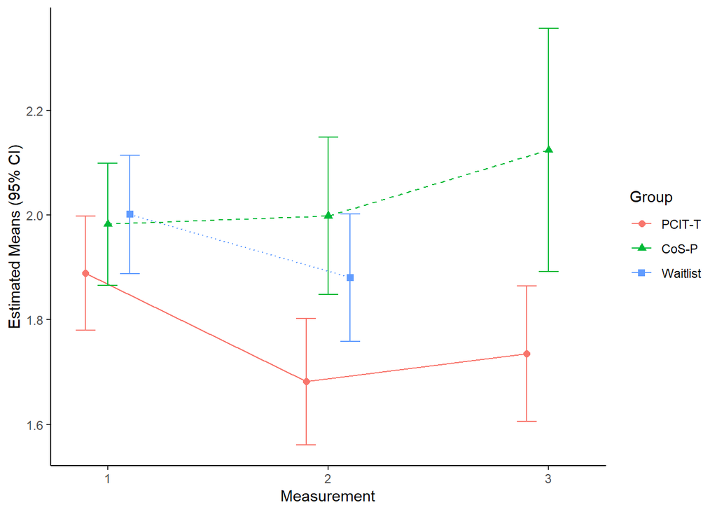

#### Hypothesis 1

We hypothesize that from baseline (‘T1’) to post-treatment/waitlist (‘T2’) there will be a gradient effect, whereby parent-child dyads who receive PCIT-T will show the greatest gains and parent-child dyads who receive no treatment will show the least gains. For the outcome, then, the null hypothesis is:

$H_0: \text {mean change}(\text{PCIT-T}) = \text {mean change}(\text{CoS-P}) = \text {mean change}(\text{Waitlist})$ $H_A: \text {mean change}(\text{PCIT-T}) > \text {mean change}(\text{CoS-P}) > \text {mean change}(\text{Waitlist})$

This is a joint hypothesis test.

First, confirming that the ordering of the means is as hypothesized:

```
## group = 1:
##  contrast estimate     SE   df t.ratio p.value
##  1 - 2      0.2074 0.0532 74.9   3.899  0.0006
##  1 - 3      0.1541 0.0590 76.6   2.612  0.0288
##  2 - 3     -0.0534 0.0612 71.9  -0.873  0.6591
##
## group = 2:
##  contrast estimate     SE   df t.ratio p.value
##  1 - 2     -0.0159 0.0692 88.1  -0.230  0.9713
##  1 - 3     -0.1417 0.1132 92.9  -1.252  0.4262
##  2 - 3     -0.1258 0.1166 83.8  -1.079  0.5297
##
## group = 3:
##  contrast estimate     SE   df t.ratio p.value
##  1 - 2      0.1210 0.0544 76.8   2.225  0.0733
##  1 - 3      nonEst     NA   NA      NA      NA
##  2 - 3      nonEst     NA   NA      NA      NA
##
## Results are averaged over the levels of: asdcase
## Degrees-of-freedom method: kenward-roger
## P value adjustment: tukey method for comparing a family of 3 estimates
```

```
##   (Intercept) asdcase1 group2 group3 time2 time3 group2:time2 group3:time2
## 1           0        0      0      0     0     0           -1            0
## 2           0        0      0      0     0     1            0            1
##   group2:time3
## 1            0
## 2            0
```

```
##
##   General Linear Hypotheses
##
## Linear Hypotheses:
##        Estimate
## 1 == 0  -0.2234
## 2 == 0  -0.0676
##
## Global Test:
##       F DF1 DF2 Pr(>F)
## 1 4.308   2 147 0.0152
```

#### Hypothesis 2

There will be a gradient of size of change from T2 to T3 such that the change in the PCIT-T group > the change in the CoS-P group. This isn’t really a gradient; it’s just 1 hypothesis.

First, the change in PCITT and COSP from time 2 to time 3:

```
## group = 1:
##  contrast estimate     SE   df t.ratio p.value
##  1 - 2      0.2074 0.0532 74.9   3.899  0.0006
##  1 - 3      0.1541 0.0590 76.6   2.612  0.0288
##  2 - 3     -0.0534 0.0612 71.9  -0.873  0.6591
##
## group = 2:
##  contrast estimate     SE   df t.ratio p.value
##  1 - 2     -0.0159 0.0692 88.1  -0.230  0.9713
##  1 - 3     -0.1417 0.1132 92.9  -1.252  0.4262
##  2 - 3     -0.1258 0.1166 83.8  -1.079  0.5297
##
## group = 3:
##  contrast estimate     SE   df t.ratio p.value
##  1 - 2      0.1210 0.0544 76.8   2.225  0.0733
##  1 - 3      nonEst     NA   NA      NA      NA
##  2 - 3      nonEst     NA   NA      NA      NA
##
## Results are averaged over the levels of: asdcase
## Degrees-of-freedom method: kenward-roger
## P value adjustment: tukey method for comparing a family of 3 estimates
```

```
##
##   Simultaneous Tests for General Linear Hypotheses
##
## Fit: lmer(formula = outcome ~ asdcase + group * time + (1 | id), data = dat)
##
## Linear Hypotheses:
##        Estimate Std. Error z value Pr(>|z|)
## 1 == 0  0.07244    0.13115   0.552    0.581
## (Adjusted p values reported -- single-step method)
```

p>0.05.

#### Residuals

Assumptions of the model are met.

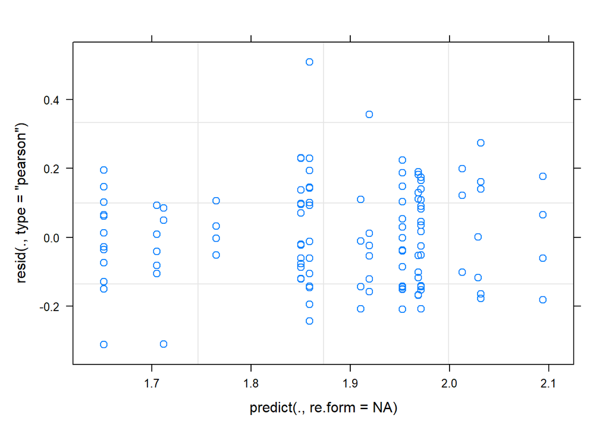

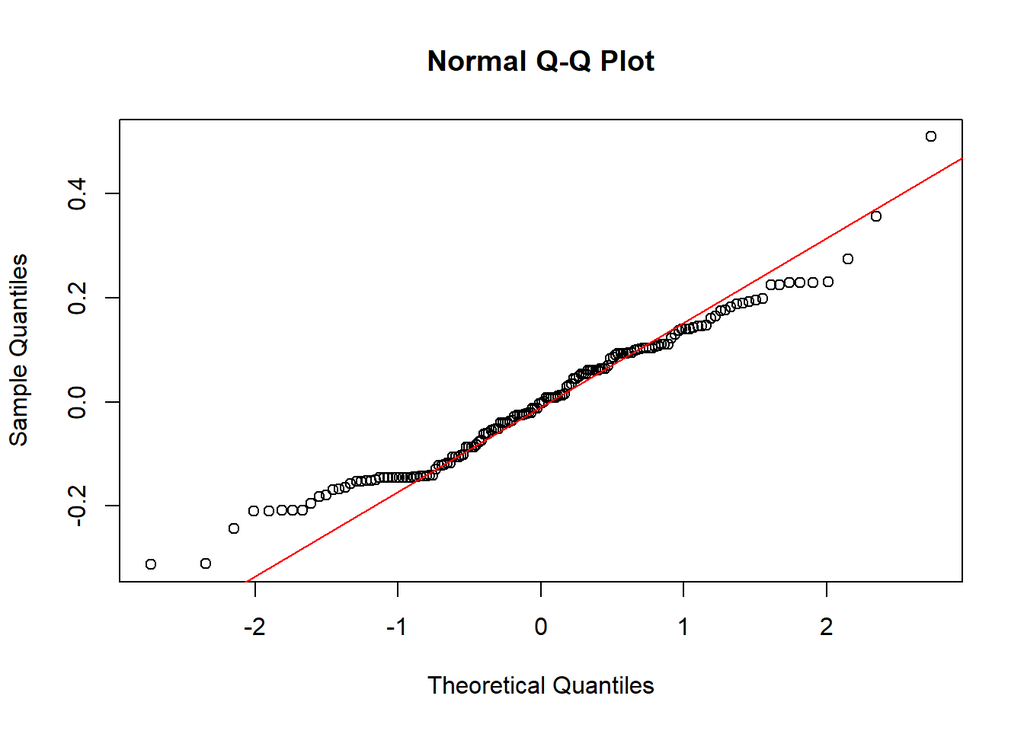

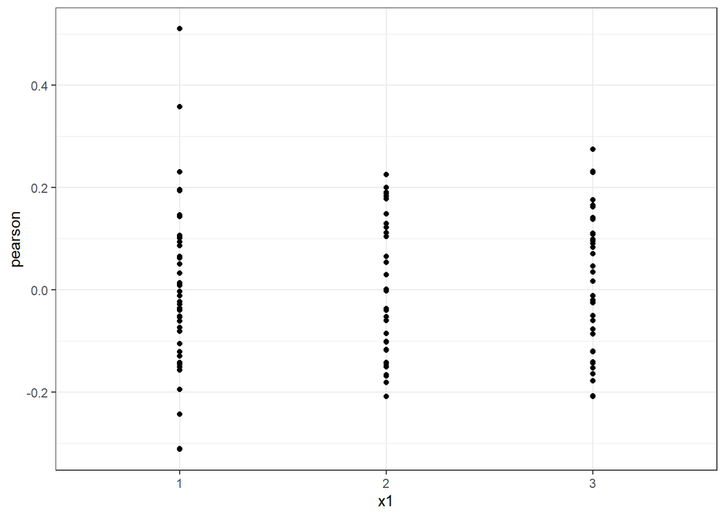

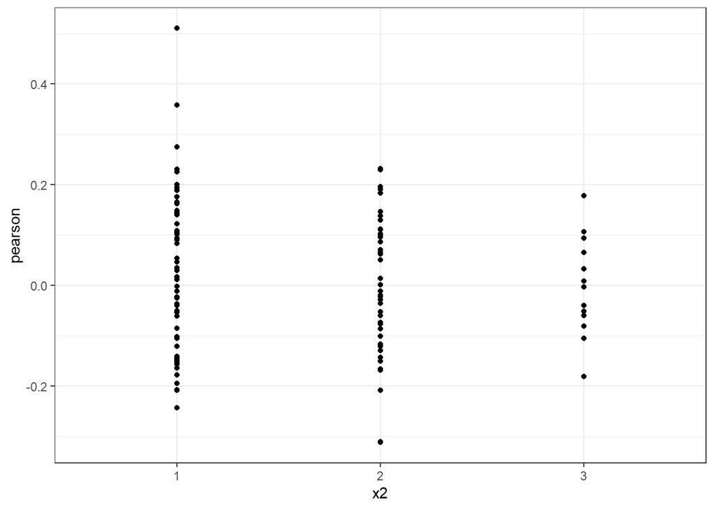

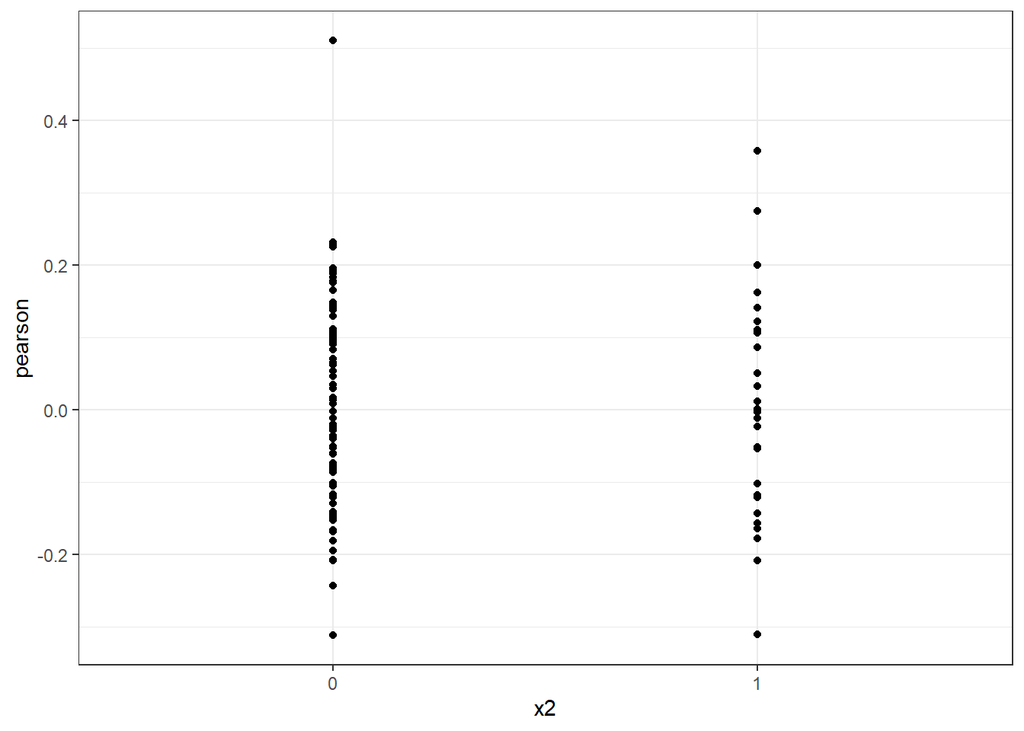

```r
rm(list = ls())
```